# Quantification File Preparation and Filtering for DGE Analysis

Amanda D. Clark

## Count file Preparation

For Salmon output (but also works for stringtie and Kallisto outputs), best practices use `tximport` to merge counts from different samples and summarize them at a gene level (so this means it accepts transcript level counts) for downstream DGE analyses. Run `?tximport` in the console for more information about `tximport` or checkout [their site](https://bioconductor.org/packages/release/bioc/html/tximport.html).  
Here is a [nice vignette](http://bioconductor.org/packages/release/bioc/vignettes/tximport/inst/doc/tximport.html#Introduction) on using tximport from different quantification methods for different DGE pipelines. ### Setting Up Environment

```r
# clear workspace
rm(list=ls(all.names=TRUE))

# install BiocManager if not installed
if (!requireNamespace("BiocManager", quietly = TRUE))
    install.packages("BiocManager")
# install tximport
#BiocManager::install("tximport")
# install rhdf5 for kallisto files
#BiocManager::install("rhdf5")
# install DESeq2
#BiocManager::install("DESeq2")
# install edgeR
#BiocManager::install("edgeR")
library(devtools)
library(tidyverse)
library(readr)
library(tximport)
library(rhdf5)
library(DESeq2)
library(SummarizedExperiment)
library(edgeR)

# directory for input files
dir <- "../R_inputs"

# check to see if make a directory for output files
if (! dir.exists("../R_outputs")) {
  dir.create("../R_outputs")
}

if (! dir.exists("../R_outputs/QuantPrep_Filter")) {
dir.create("../R_outputs/QuantPrep_Filter")
}
```

### Setting up Input Files

This usually requires a tx2gene file: > Transcripts need to be associated with gene IDs for gene-level summarization. If that information is present in the files, we can skip this step. For Salmon, Sailfish, and kallisto the files only provide the transcript ID. We first make a data.frame called tx2gene with two columns: 1) transcript ID and 2) gene ID. The column names do not matter but this column order must be used. The transcript ID must be the same one used in the abundance files.

I found a [function](https://jmw86069.github.io/splicejam/reference/makeTx2geneFromGtf.html) `makeTx2geneFromGtf` in the package `splicejam` that will generate a necessary file “tx2gene” for `tximport`, but I couldn’t get the function above to work for me. Possible explanations:

1. I am not specifying the necessary information (I think it needs a GTF, and what the values in column 9 and column 3 are for each sample)
2. The gtf is not formatted in a recognizable way. This GTF was output from RSEM from a gff3 output from [Funannotate](https://funannotate.readthedocs.io/en/latest/)

Well, either way, you’ll notice that this is just a key of transcript and corresponding gene id’s, which we could make from the GTF ourselves

```r
# GTF file to make required file "tx2gene" for tximport (Alternative Route)
mygtf <- "../R_inputs/Daphnia_pulex.gtf"

# import mygtf as a data table, select the attribute column (9) from gtf
gtfatr <- data.table::fread(mygtf) %>% select("V9") %>% unique()

# split attribute column into gene_id and transcript_id, and rearrange the columns in the required order
gtfatr <- separate(gtfatr,1,c("gene_id", "transcript_id"), sep = ";") %>% select(c("transcript_id","gene_id"))
# isolating FUN# ID for each attribute
gtfatr$gene_id<- gsub("gene_id \"(FUN_[0-9]+)\"","\\1", gtfatr$gene_id)
gtfatr$transcript_id<- gsub("transcript_id \"(FUN_[0-9]+-T1)\"","\\1", gtfatr$transcript_id)
head(gtfatr)
```

| transcript_id | gene_id |
| --- | --- |
| FUN_000057-T1 | FUN_000057 |
| FUN_000056-T1 | FUN_000056 |
| FUN_000055-T1 | FUN_000055 |
| FUN_000054-T1 | FUN_000054 |
| FUN_000053-T1 | FUN_000053 |
| FUN_000052-T1 | FUN_000052 |

```r
# export file in case it is necessary downstream
if (! file.exists("../R_inputs/tx2gene_dpulex.csv")){
  write.csv(gtfatr, "../R_inputs/tx2gene_dpulex.csv", row.names = F)
}
```

```r
# input samples and metadata
samples <- read.table(file.path(dir, "samples.txt"), header = T)
head(samples)
```

|  | SRRID | LIBNAME | SAMPNAME |
| --- | --- | --- | --- |
| 1 | SRR6819014 | C4 | C4 |
| 2 | SRR6819015 | C5 | C5 |
| 3 | SRR6819016 | C2 | C2 |
| 4 | SRR6819017 | C3 | C3 |
| 5 | SRR6819018 | E2 | E2 |
| 6 | SRR6819019 | E3 | E3 |

```r
# input tx2gene file if it wasn't already generated here
#tx2gene <- read_csv(file.path(dir, "tx2gene_dpulex.csv"))
tx2gene <- gtfatr
head(tx2gene)
```

| transcript_id | gene_id |
| --- | --- |
| FUN_000057-T1 | FUN_000057 |
| FUN_000056-T1 | FUN_000056 |
| FUN_000055-T1 | FUN_000055 |
| FUN_000054-T1 | FUN_000054 |
| FUN_000053-T1 | FUN_000053 |
| FUN_000052-T1 | FUN_000052 |

```r
length(tx2gene$gene_id)
```

```
[1] 16612
```

### Running tximport for Salmon, Kallisto, & Stringtie File Imports

#### Salmon

```r
# make list of all quant.sf files for samples from the same project.
files <- file.path(dir, "salmon_counts", samples$SRRID, "quant.sf")

# check to make sure all of the files from the "list" can be found
all(file.exists(files))
```

```
[1] TRUE
```

```r
# summarize counts from Salmon quantification
txi.salmon <- tximport(files, type = "salmon", tx2gene = tx2gene)
```

```
reading in files with read_tsv
1 2 3 4 5 6 7 8 9 10
summarizing abundance
summarizing counts
summarizing length
```

```r
# check out the counts
head(txi.salmon$counts)
```

```
           [,1]   [,2]  [,3]  [,4] [,5]   [,6]   [,7]     [,8]    [,9]    [,10]
FUN_000001   28  39.50  29.5  24.5   40  38.00  32.00   27.000  36.000   47.500
FUN_000002   24  35.00  29.0  24.5    9  11.50  21.50    4.000   0.500    3.500
FUN_000003    2   3.47   4.0   0.0    0   1.17   1.31    2.438   0.000    4.049
FUN_000004  127 153.00 158.0 193.0  168 134.00 170.00  121.000 126.000  199.000
FUN_000005  495 730.00 487.0 606.0  980 884.00 945.00 1026.000 980.001 1322.000
FUN_000006   71 116.00  87.0  97.0  178 133.00 128.00  192.000 170.000  230.000
```

#### Kallisto

```r
# make list of all abundance.h5 files for samples from the same project.
files <- file.path(dir, "kallisto_counts", samples$SRRID, "abundance.h5")

# metadata table with a column for filenames
kallisto_coldata <- cbind(samples, files = files, stringsAsFactors = FALSE)

# summarize counts from Kallisto quantification
txi.kallisto <- tximport(files, type = "kallisto", tx2gene = tx2gene)
```

```
1 2 3 4 5 6 7 8 9 10
summarizing abundance
summarizing counts
summarizing length
```

```r
# check out the counts
head(txi.kallisto$counts)
```

```
                 [,1]      [,2]      [,3]       [,4]        [,5]       [,6]        [,7]       [,8]      [,9]      [,10]
FUN_000001  29.000000  42.00000  33.00000  26.000000   44.000000   39.00000   33.500000   29.50000   37.0000   51.00000
FUN_000002  26.500000  36.50000  33.00000  29.500000   10.500000   12.00000   23.000000    5.00000    0.5000    3.50000
FUN_000003   9.718803  18.91088  19.56501   6.516404    7.530646   15.32486    6.009325   21.62354   12.4342   17.00646
FUN_000004 149.000000 175.08780 181.00000 208.000000  190.000000  141.00000  189.090175  136.00000  148.1041  240.12608
FUN_000005 637.000000 920.00000 634.00000 766.000000 1255.000000 1151.00000 1212.000000 1312.00000 1237.0000 1681.00000
FUN_000006 107.000000 153.00000 120.00000 141.000000  259.000000  190.00000  174.000000  250.00000  223.0000  319.00000
```

#### Stringtie

```r
## Star
# make list of all t_data.ctab files for samples from the same project.
files <- file.path(dir, "stringtie_counts_star", samples$SRRID, "t_data.ctab")

# metadata table with a column for filenames
stringties_coldata <- cbind(samples, files = files, stringsAsFactors = FALSE)

# summarize counts from stringtie quantification
txi.stringties <- tximport(files, type = "stringtie", tx2gene = tx2gene)
```

```
reading in files with read_tsv
1 2 3 4 5 6 7 8 9 10
summarizing abundance
summarizing counts
summarizing length
```

```r
# check out the counts
head(txi.stringties$counts)
```

```
                 [,1]       [,2]       [,3]       [,4]        [,5]        [,6]        [,7]        [,8]       [,9]       [,10]
FUN_000001   53.37999   63.94668   53.85334   41.51334   76.393353   76.520014   65.540015   51.355554   64.86667   90.693330
FUN_000002   45.17333   62.74000   46.74666   50.32000   19.306669   22.440005   43.020001    6.666659    0.00000    6.233339
FUN_000003    0.00000    0.00000    0.00000    0.00000    3.382233    4.348896    2.513333    0.000000    0.00000    0.000000
FUN_000004  240.81332  273.04000  286.92000  340.63998  317.513342  257.560011  306.853326  221.200005  231.13332  356.466675
FUN_000005 1020.86436 1408.55435 1010.38440 1166.37333 2078.804488 1994.486594 2023.986550 2187.119936 2023.44674 2598.588870
FUN_000006  153.69337  214.59999  180.74221  188.75999  384.566657  322.226675  294.213333  385.533347  351.45332  437.186670
```

```r
## Hisat2
# make list of all t_data.ctab files for samples from the same project.
files <- file.path(dir, "stringtie_counts_hisat2", samples$SRRID, "t_data.ctab")

# metadata table with a column for filenames
stringtieh_coldata <- cbind(samples, files = files, stringsAsFactors = FALSE)

# summarize counts from stringtie quantification
txi.stringtieh <- tximport(files, type = "stringtie", tx2gene = tx2gene)
```

```
reading in files with read_tsv
1 2 3 4 5 6 7 8 9 10
summarizing abundance
summarizing counts
summarizing length
```

```r
# check out the counts
head(txi.stringtieh$counts)
```

```
                 [,1]        [,2]       [,3]       [,4]        [,5]        [,6]       [,7]        [,8]       [,9]       [,10]
FUN_000001   45.90666   68.713346   49.47332   47.10667   79.226674   76.033322   59.06666   52.186658   63.69999   89.773336
FUN_000002   34.34667   42.859996   49.53334   40.40666   14.486674   18.680009   33.66667    4.553325    0.00000    5.693336
FUN_000003    0.00000    6.966667    0.00000    0.00000    5.111119    4.301119    0.00000    3.306666    0.00000    0.000000
FUN_000004  250.37334  284.146674  298.73333  361.26666  322.440002  261.039990  323.97333  231.440010  236.90666  373.960000
FUN_000005 1035.97327 1424.833298 1016.54667 1208.74667 2052.666778 1949.933303 2022.93997 2160.133276 2041.93343 2645.153265
FUN_000006  170.06668  237.986670  192.46667  213.29333  410.986660  329.093331  301.85336  418.480016  374.44000  483.106676
```

You will notice that some of these aren’t integers, but they should be. This [tutorial resource](https://uclouvain-cbio.github.io/BSS2019/rnaseq_gene_summerschool_belgium_2019.html#summarizing-an-rna-seq-experiment-as-a-count-matrix) from a bioinformatics summer school suggests rounding these values.

```r
# round counts
txi.salmon$counts <- round(txi.salmon$counts)
txi.kallisto$counts <- round(txi.kallisto$counts)
txi.stringtieh$counts <- round(txi.stringtieh$counts)
txi.stringties$counts <- round(txi.stringties$counts)

# convert to matrix
counts_salmon <- as.matrix(txi.salmon$counts)
counts_kallisto <- as.matrix(txi.kallisto$counts)
counts_strgtieh <- as.matrix(txi.stringtieh$counts)
counts_strgties <- as.matrix(txi.stringties$counts)

# check it out
head(counts_salmon)
```

```
           [,1] [,2] [,3] [,4] [,5] [,6] [,7] [,8] [,9] [,10]
FUN_000001   28   40   30   24   40   38   32   27   36    48
FUN_000002   24   35   29   24    9   12   22    4    0     4
FUN_000003    2    3    4    0    0    1    1    2    0     4
FUN_000004  127  153  158  193  168  134  170  121  126   199
FUN_000005  495  730  487  606  980  884  945 1026  980  1322
FUN_000006   71  116   87   97  178  133  128  192  170   230
```

```r
head(counts_kallisto)
```

```
           [,1] [,2] [,3] [,4] [,5] [,6] [,7] [,8] [,9] [,10]
FUN_000001   29   42   33   26   44   39   34   29   37    51
FUN_000002   26   36   33   30   10   12   23    5    0     4
FUN_000003   10   19   20    7    8   15    6   22   12    17
FUN_000004  149  175  181  208  190  141  189  136  148   240
FUN_000005  637  920  634  766 1255 1151 1212 1312 1237  1681
FUN_000006  107  153  120  141  259  190  174  250  223   319
```

```r
head(counts_strgties)
```

```
           [,1] [,2] [,3] [,4] [,5] [,6] [,7] [,8] [,9] [,10]
FUN_000001   53   64   54   42   76   77   66   51   65    91
FUN_000002   45   63   47   50   19   22   43    7    0     6
FUN_000003    0    0    0    0    3    4    3    0    0     0
FUN_000004  241  273  287  341  318  258  307  221  231   356
FUN_000005 1021 1409 1010 1166 2079 1994 2024 2187 2023  2599
FUN_000006  154  215  181  189  385  322  294  386  351   437
```

```r
head(counts_strgtieh)
```

```
           [,1] [,2] [,3] [,4] [,5] [,6] [,7] [,8] [,9] [,10]
FUN_000001   46   69   49   47   79   76   59   52   64    90
FUN_000002   34   43   50   40   14   19   34    5    0     6
FUN_000003    0    7    0    0    5    4    0    3    0     0
FUN_000004  250  284  299  361  322  261  324  231  237   374
FUN_000005 1036 1425 1017 1209 2053 1950 2023 2160 2042  2645
FUN_000006  170  238  192  213  411  329  302  418  374   483
```

```r
# output pre-filtered files
write_csv(rownames_to_column(data.frame(counts_kallisto, row.names = row.names(counts_kallisto)), "gene_id"), "../R_outputs/QuantPrep_Filter/unfiltered_kallisto.csv")
write_csv(rownames_to_column(data.frame(counts_salmon, row.names = row.names(counts_salmon)), "gene_id"), "../R_outputs/QuantPrep_Filter/unfiltered_salmon.csv")
write_csv(rownames_to_column(data.frame(counts_strgtieh, row.names = row.names(counts_strgtieh)), "gene_id"), "../R_outputs/QuantPrep_Filter/unfiltered_strgtieh.csv")
write_csv(rownames_to_column(data.frame(counts_strgties, row.names = row.names(counts_strgties)), "gene_id"), "../R_outputs/QuantPrep_Filter/unfiltered_strgties.csv")
```

### HTSeq File Import

HTSeq generates gene level outputs, but tximport takes in transcript abundance data. Seeing as there is a single transcript per gene, this really shouldn’t matter for the transcript to gene level conversion tximport does.

```r
# File and sample dataframe
htseqs_coldata <- cbind(samples, files = files, stringsAsFactors = FALSE)

## Star
# make list of all *_star_htscount.txt files for samples from the same project.
files <- file.path(dir, "htseq_counts_star", samples$SRRID, paste0(samples$SRRID,"_star_htscount.txt"))
# check to make sure all of the files from the "list" can be found
all(file.exists(files))
# import files from list...
counts_htss <- files %>%
  map(read_delim, col_name = FALSE ) %>%
  # merge the columns from each sample
  purrr::reduce(inner_join, by = "X1") %>%
  # remove the last five lines (summary information from HTSeq)
  filter(row_number() <= n()-5)
# get gene names
rnames <- c(counts_htss$X1)
# remove column with gene names (will get put back later, but best to format data all of the same way for processing) and convert to matrix
counts_htss <- counts_htss %>% select(-1) %>% as.matrix()
# set rownames and colnames of the matrix
rownames(counts_htss) <- rnames
colnames(counts_htss) <- NULL



## Hisat2
# repeat steps for hisat htseq counts
files <- file.path(dir, "htseq_counts_hisat2", samples$SRRID, paste0(samples$SRRID,"_hisat2_htscount.txt"))
# check to make sure all of the files from the "list" can be found
all(file.exists(files))
# import files from list...
counts_htsh <- files %>%
  map(read_delim, col_name = FALSE ) %>%
  # merge the columns from each sample
  purrr::reduce(inner_join, by = "X1") %>%
  # remove the last five lines (summary information from HTSeq)
  filter(row_number() <= n()-5)
# get gene names
rnames <- c(counts_htsh$X1)
# remove column with gene names (will get put back later, but best to format data all of the same way for processing) and convert to matrix
counts_htsh <- counts_htsh %>% select(-1) %>% as.matrix()
# set rownames and colnames of the matrix
rownames(counts_htsh) <- rnames
colnames(counts_htsh) <- NULL

head(counts_htsh)

# output pre-filtered files
write_csv(rownames_to_column(data.frame(counts_htss, row.names = row.names(counts_htss)), "gene_id"), "../R_outputs/QuantPrep_Filter/unfiltered_htss.csv")
write_csv(rownames_to_column(data.frame(counts_htsh, row.names = row.names(counts_htsh)), "gene_id"), "../R_outputs/QuantPrep_Filter/unfiltered_htsh.csv")
```

[output not shown]

### Quick Method Comparison

I wanted to get a quick look at the variation in transcript (in our case, each transcript is a gene because each gene has exactly one transcript-dunno why, something to look into-) counts between the two alternative mapping/counting methods. I found [this tutorial](https://uclouvain-cbio.github.io/BSS2019/rnaseq_gene_summerschool_belgium_2019.html) from a bioinformatics summer school in 2019.

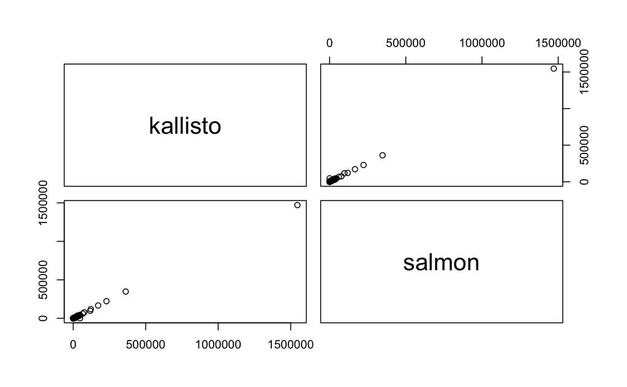

```r
# Pick a sample
smp <- 1
# Get row names from one of the count dataframes
gns <- rownames(counts_kallisto)

# Make a dataframe with the selected sample gene-level counts from kallisto and salmon
quant <- data.frame(kallisto = counts_kallisto[gns, smp],
                    salmon = counts_salmon[gns, smp])
pairs(quant)
```

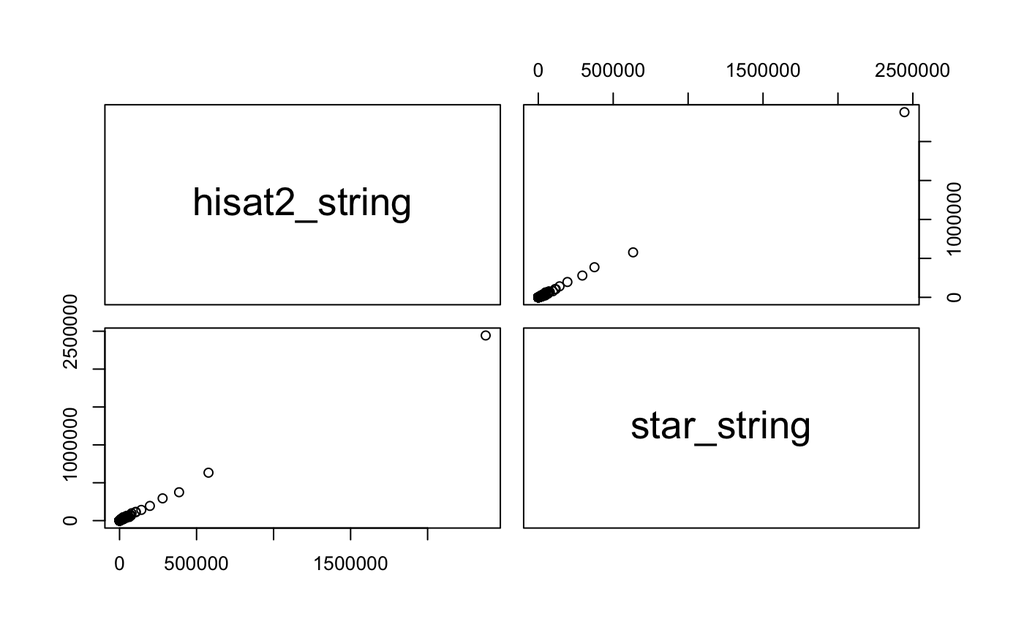

```r
# Make a dataframe with the selected sample gene-level counts from stringtie with star and hisat2
quant <- data.frame(hisat2_string = counts_strgtieh[gns, smp],
                    star_string = counts_strgties[gns, smp])
pairs(quant)
```

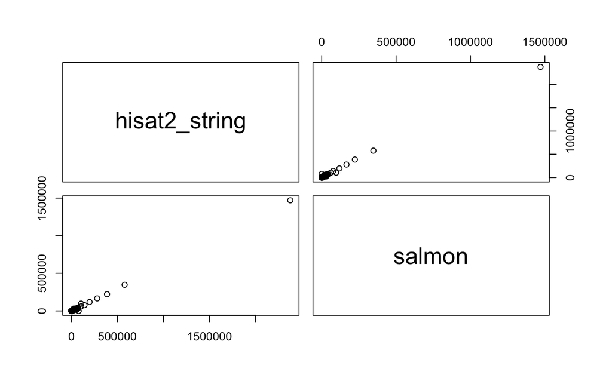

```r
# Make a dataframe with the selected sample gene-level counts from stringtie with star or hisat2 kallisto or salmon
quant <- data.frame(hisat2_string = counts_strgtieh[gns, smp],
                   salmon = counts_salmon[gns, smp])
pairs(quant)
```

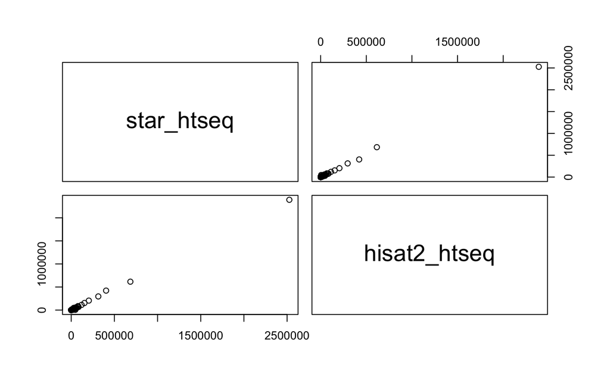

```r
# Make a dataframe with the selected sample gene-level counts from HTSeq with star and hisat2
quant <- data.frame(star_htseq = counts_htss[gns, smp],
                   hisat2_htseq = counts_htsh[gns, smp])
pairs(quant)
```

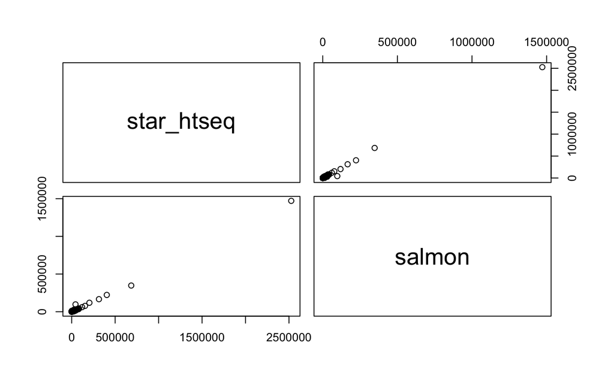

```r
# Make a dataframe with the selected sample gene-level counts from HTSeq with star or hisat2 kallisto or salmon
quant <- data.frame(star_htseq = counts_htss[gns, smp],
                   salmon = counts_salmon[gns, smp])
pairs(quant)
```

```r
# I was getting an error: "Error in counts_salmon[gns, smp] : subscript out of bounds"
# Pulling out that sample from kallisto and salmon...How many genes are in each of these outputs? Tip: You can also get the number of genes by looking at the "Environment" pane in Rstudio. the number of elements in the matrix (here, counts_[kallisto|salmon]).
length(counts_kallisto[,1])
length(counts_salmon[,1])
length(counts_strgtieh[,1])
length(counts_strgties[,1])
length(counts_htss[,1])
length(counts_htsh[,1])

# List of duplicate transcripts from Salmon
genedup <- read_tsv("../R_inputs/duplicate_clusters.tsv")

# Removing the -T1 from the gene ids
genedup$DuplicateRef <- gsub("-T1","",genedup$DuplicateRef)
head(genedup, 2)

# Compare expression at those rows from the 1st duplicate from the dataframe
counts_kallisto["FUN_004312", ]
counts_kallisto["FUN_015313", ]

# The FAQ link above addresses this. Briefly, duplicated genes will have the same counts, as demonstrated here. I could remove duplicate gene ids from other count methods.
rmv <- c(genedup[,2])
length(counts_kallisto[ ! rownames(counts_kallisto) %in% rmv, ])
```

[output not shown]